# Expected Value and Variance

# Overview

- Expected Value
- Joint Densities and Independence
- Variance
  - Expected value of $\phi(X)$
- Important Identities

For further reading, see [GS], pp. 268-275

# Expected Value

## General Idea:

**Expected Value** $E(X)$. Out of all the values a given random variable $X$ can take, what value, on average, do we expect to see?

1. Standard Normal: $E(Z) = 0$.
2. Exponential?
   $$f(x) = \begin{cases}
   \lambda e^{-\lambda x} & \text{if } x \geq 0 \\
   0 & \text{otherwise}
   \end{cases}$$

## Motivation: Simulation

Let $\lambda = 3$. We can take random draws of the exponential distribution and compute the average.

```r
set.seed(1231)
expDraw <- rexp(10000, rate = 3)
mean(expDraw)
```

```
[1] 0.3320952
```

## Motivation: Discrete Case

If $X$ is a discrete random variable with mass function $m(x)$, the expected value would just be the average value, weighted by probability.

$$E(X) = \sum_{x \in \Omega} x \cdot m(x)$$

Example: Flip 3 coins

## Expected Value of a Continuous Random Variable

Let $X$ be a continuous random variable with density function $f(x)$, and suppose that $\int_{-\infty}^\infty |x| f(x) \, dx$ is finite. Then the **expected value** of $X$ is
$$\mu = E(X) = \int_{-\infty}^\infty x f(x) \, dx$$

Example: Exponential with $\lambda = 3$.

## Linearity Properties

Suppose that $X$ and $Y$ are random variables and $c$ is a constant. The first of the following rules follows immediately from rules for integrals. The second rule, while intuitively plausible, requires some multivariable machinery to prove (see [ER], page 144).

- $E(cX) = c(E(X))$
- $E(X + Y) = E(X) + E(Y)$

# Joint Density Functions

## Motivating example

1. Consider drawing a point at random from the square region $[0,1] \times [0,1]$. Let $X$ and $Y$ be the coordinates of the point.
2. Consider drawing a point at random from the region bounded by the triangle with vertices $(0,0)$, $(1,0)$, and $(0,1)$. Let $X$ and $Y$ be the coordinates of the point.

In each case, does the distribution of $Y$ depend on the value of $X$ (and vice versa)?

## Independence

Two continuous random variables $X$ and $Y$ are **independent** if the conditional PDF for $X$ given $Y = y$ does not depend on $y$. That is, for any value of $y$,
$$f_{X \mid Y}(x \mid Y = y) = f_X(x)$$
is a function of $x$ only (and not $y$).

## Double integrals

- A (positive, continuous) function of two variables $z = f(x,y)$ defines a surface (above the $xy$-plane).
- The *volume* between a region $E$ in the $xy$-plane and the surface is given by the **double integral**
  $$\iint_E f(x,y)\, dy \, dx$$

## Joint density functions

Suppose the sample space $\Omega$ is two-dimensional: $\Omega \subseteq \mathbb{R}^2$. In this case we can consider random variables $(X, Y)$ drawn from this sample space, and an event $E$ is a two-dimensional region in $\Omega$. A **joint density function** for $X$ and $Y$ is a function $f(x,y)$ such that
$$P((X,Y)\in E) = \iint_E f(x,y) dy \, dx$$

## Joint cumulative distribution functions

Similarly, we can define the **joint cumulative distribution function** for $X$ and $Y$ as
$$F(x,y) = P(X \leq x \text{ and } Y \leq y)$$

Facts: $f$ and $F$ are related as follows.
$$F(x,y) = \int_{-\infty}^x \int_{-\infty}^y f(s,t) \, dt \, ds$$
and
$$f(x,y) = \frac{\partial^2F(x,y)}{\partial x \partial y}$$

## Equivalent conditions for independence

Suppose $X$ and $Y$ are continuous random variables with PDFs $f_X(x)$ and $f_Y(y)$ and CDFs $F_X(x)$ and $F_Y(y)$. Then either of the following conditions imply that $X$ and $Y$ are independent.

- The joint density function $f(x,y) = f_X(x) f_Y(y)$.
- The joint distribution function $F(x,y) = F_X(x)F_Y(y)$.

For more details, see [ER], pp. 95-100.

## Expected Value of a Product

**Theorem 6.12.** Let $X$ and $Y$ be independent real-valued continuous random variables with finite expected values. Then $E(XY) = E(X)E(Y)$.

# Variance

## Expected Value of a Function of a Random Variable

**Theorem 6.11.** Let $X$ be a continuous random variable with density function $f(x)$, and suppose $\phi$ is a real-valued function. Then
$$E(\phi(X)) = \int_{-\infty}^\infty \phi(x) f(x) \, dx$$

The proof is technical. Some special cases are easy.

## Exercise

A stick of length 1 (on the interval $[0, 1]$) contains a knot a third of the way from one end (at $x = 1/3$). The stick is cut in two pieces at a point $X$ that is uniformly distributed on $[0,1]$. Find the expected length of the piece containing the knot.

The length of this piece will be $\phi(U)$, where
$$\phi(U) = \begin{cases}
1 - U & \text{if } U < 1/3 \\
U & \text{if } U > 1/3.
\end{cases}$$

Now apply Theorem 6.11.

## Variance: motivation

We want to measure how spread out the distribution of a given random variable is.

Smaller variance

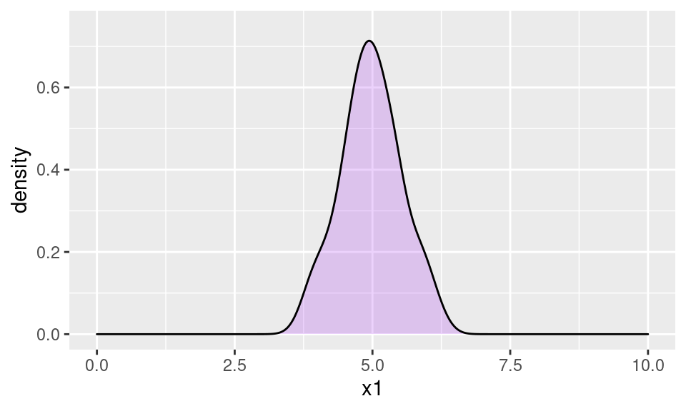

Larger variance

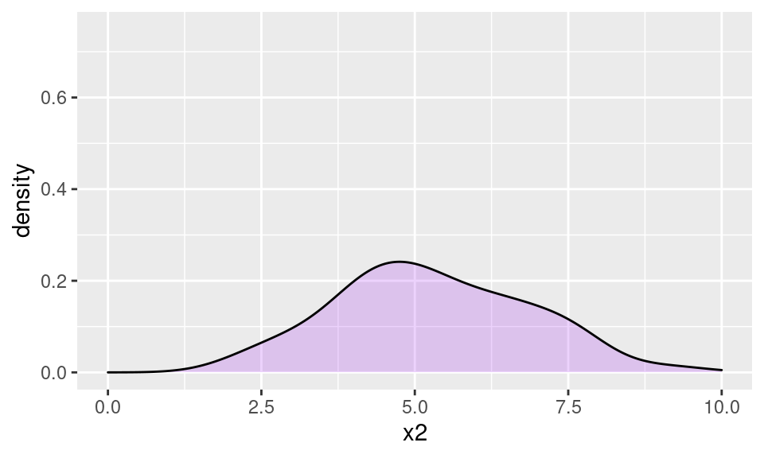

## Variance

The **variance** $V(X) = \sigma^2$ of a random variable $X$ is the expected squared distance from the mean:
$$V(X) = \sigma^2 = E((X-\mu)^2) = \int_{-\infty}^\infty (x - \mu)^2 f(x)
\, dx$$

In this formula, $\mu = E(X)$ and $\sigma$ is called the **standard deviation**.

Example: Variance of Standard Normal

## Properties of Variance

**Theorem 6.14.** Let $X$ be a continuous random variable and $c$ a constant.

- $V(cX) = c^2V(X)$
- $V(X + c) = V(X)$
- Proof: Properties of integrals
- Application: Mean and variance of Normal with parameters $\mu$ and $\sigma$.

## Shortcut Formula

**Theorem 6.15.** $V(X) = E(X^2) - [E(X)]^2 = E(X^2) - \mu^2$.

$${\small \begin{align}
V(X) &= E(X - \mu)^2 \\
&= E(X^2 - 2X\mu +\mu^2) \\
&= E(X^2) -2\mu E(x) + \mu^2 \\
&= E(X^2) -2\mu^2 + \mu^2 = E(X^2) - \mu^2
\end{align}}$$

## Addition Rule for Variance

**Theorem 6.16.** If $X$ and $Y$ are *independent* random variables, then
$$V(X + Y) = V(X) + V(Y)$$

$$\begin{align}
V(X + Y) &= E((X+Y)^2) - [E(X+Y)]^2\\
&= E(X^2 + 2XY + Y^2) - [E(X) + E(Y)]^2 \\
&= E(X^2) + 2E(X)E(Y) + E(Y^2) - [(E(X))^2 + 2E(X)E(Y) + (E(Y))^2]
\\
&= E(X^2) - [E(X)]^2 + E(Y^2) - [E(Y)]^2 = V(X) + V(Y)
\end{align}$$

## Application: Independent Trials

- Random samples are important in statistical studies.
- **Theoretical Assumptions.** A random sample of $n$ observations corresponds to *independent, identically-distributed* (iid) random variables $X_1, X_2, \ldots X_n$.
- Suppose $E(X_i) = \mu$ and $V(X_i) = \sigma^2$ for all $i$.
- The **sample mean** is then a random variable $\bar{X} = (X_1 + X_2 + \cdots + X_n)/n$.
  - $E(\bar{X}) = \mu$
  - $V(\bar{X}) = \sigma^2/n$